# Image Captioner

Made by SeanvonB | [Source](https://github.com/SeanvonB/image-captioner)

This is another project that was part of my [Computer Vision Nanodegree](https://www.udacity.com/course/computer-vision-nanodegree--nd891) from 2020. In this notebook, I cover the process of developing an image captioner: a network that receives an image and returns a written description of the image. It combines Convolutional Neural Networks (CNNs) and Recurrent Neural Networks (RNNs) with Long Short-Term Memory (LSTM) cells to create a network with both feedforward and feedback connections. Beyond the obvious but incredible difference an image captioner can make in terms of user accessibility, this project demonstrates a network that's capable of infering *contextual nuance*, which has countless other applications and is simply fascinating. On the other hand, this project sometimes demonstrates a network that's *incapable* of infering contextual nuance; which, while disappointing, can also be pretty funny.

Per Udacity's instruction, the project is broken down into four steps:

1. Understand the data
2. Preprocess the data
3. Train the model
4. Test the model

Let's get started!

# 1.0 Understand the Data

Image and text data for this project is provided by the Microsoft [Common Objects in Context](https://cocodataset.org/#home) dataset, or **COCO**. In addition to captioning algorithms, this dataset would be ideal for any project that relies on contextual recognition, object detection, object segmentation, and pattern recognition. You can read more about COCO [here](https://arxiv.org/abs/1405.0312).

Here's an example of the dataset that's provided by COCO itself:

[figure not shown]

As you can see, there's a pretty wide variety of contexts, as well as some objects that seemingly lack any context. Further, in addition to specialized data, like the color segmented examples shown, the images from COCO include **5 captions per image**, which will be the primary association that I will expect this network to infer. Plus, the COCO dataset can be accessed through the [COCO API](https://github.com/cocodataset/cocoapi), which significantly reduces local file space and just feels like good data science – hopefully, that will reduce the likelihood that I get an email from GitHub about their *recommended* repo size limit.

## 1.1 Initialize the COCO API

The following code will establish the connection to COCO and retrieve the dataset for storage in memory. Note that two different types of files are being imported: instance annotations and caption annotations; there will be more on this later. Finally, a list of IDs is created, so that dataset samples can be indivdually accessed if needed.

```python
  import os
  import sys
  sys.path.append('/opt/cocoapi/PythonAPI')
  from pycocotools.coco import COCO

  # Initialize COCO API for instance annotations
  dataDir = '/opt/cocoapi'
  dataType = 'val2014'
  instances_annFile = os.path.join(dataDir, 'annotations/instances_{}.json'.format(dataType))
  coco = COCO(instances_annFile)

  # Initialize COCO API for caption annotations
  captions_annFile = os.path.join(dataDir, 'annotations/captions_{}.json'.format(dataType))
  coco_caps = COCO(captions_annFile)

  # Get image IDs
  ids = list(coco.anns.keys())
```

```
loading annotations into memory...
Done (t=6.34s)
creating index...
index created!
loading annotations into memory...
Done (t=0.97s)
creating index...
index created!
```

## 1.2 Plot a Sample

Next, it's wise to check a few samples before moving on to preprocessing, which I do with two objectives in mind: (**1**) learn what format/shape a sample has, and (**2**) learn how to access each component of a sample as needed. So, I'll plot a sample image and print the corresponding captions.

If you'd like to rerun this cell, a new image and its captions will be chosen randomly each time

```
http://images.cocodataset.org/val2014/COCO_val2014_000000219820.jpg
```

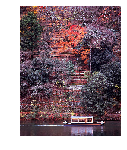

```
A small boat is going down the river in front of colorful trees.
A terraced hill in fall colors going down to the water with a boat on it.
a red blue and yellow boat and some red trees
Boat on water above trees with fall foliage.
A series of steep stairs lay next to a lake
```

```python
  import numpy as np
  import skimage.io as io
  import matplotlib.pyplot as plt
  %matplotlib inline

  # Get URL for random image
  ann_id = np.random.choice(ids)
  img_id = coco.anns[ann_id]['image_id']
  img = coco.loadImgs(img_id)[0]
  url = img['coco_url']

  # Print URL and plot image
  print(url)
  I = io.imread(url)
  plt.axis('off')
  plt.imshow(I)
  plt.show()

  # Load and print captions
  annIds = coco_caps.getAnnIds(imgIds=img['id'])
  anns = coco_caps.loadAnns(annIds)
  coco_caps.showAnns(anns)
```

I think there may already be some interesting details to note: the captions apparently don't follow a rigid pattern, e.g. verb tense isn't consistent nor are punctuation, capitalization, or article inclusion. I'm curious how this will affect the outcome and whether this may actually improve generalization.

# 2.0 Preprocess the Data

This section will cover all of the steps between acquiring the data and actually training the network, which will include transforming the data, preparing the data loader, and determining settings like batch size and how many times words must be seen by the network before they're added to the vocabulary. Lastly, this section will include importing the network.

Rather than use [PyTorch's DataLoader](http://pytorch.org/docs/master/data.html) as before, Udacity provided their own data loader in `data_loader.py` (which can be initialized with `get_loader`) and stated we were not permitted to change this file or use an alternative.

As mentioned in [previous](https://seanvonb.github.io/image-classifier/) [projects](https://seanvonb.github.io/facial-keypoint-detector/), data transforms solve two problems: first, they conform inputs to match what pre-trained models expect, which is typically a 224x224 image Tensor with color channels normalized according to ImageNet standards; second, they improve generalization by allowing us to subtly mess with the images, thereby functionally expanding the dataset. For this project, I simply resize the image to a minimum of 256 pixels, randomly extract a 224x224 segment, then horizontally mirror the image 50% of the time.

Finally, vocabulary threshold is a new variable for this kind of project. Setting a minimum number of times that words must be seen before being added to the vocabulary helps ensure that the network will take fewer gambles on words that it doesn't particularly understand. Raising this threshold will produce a network that's more correct but less descriptive, while lowering it will produce a network that's more **fun**.

Finally, the transformed data must be loaded into the data loader from `data_loader.py`.

```python
  import sys
  sys.path.append('/opt/cocoapi/PythonAPI')
  from pycocotools.coco import COCO
  %pip install nltk
  import nltk
  nltk.download('punkt')
  from data_loader import get_loader
  from torchvision import transforms

  # Define a transform to pre-process the training images
  transform_train = transforms.Compose([
      transforms.Resize(256),                          # Resize smallest dim to 256 pixels
      transforms.RandomCrop(224),                      # Randomly crop 224x224 segment
      transforms.RandomHorizontalFlip(),               # Horizontal mirror with probability=0.5
      transforms.ToTensor(),                           # Convert PIL to Tensor
      transforms.Normalize((0.485, 0.456, 0.406),      # Normalize image for pre-trained model
                          (0.229, 0.224, 0.225))])

  # Specify the batch size
  batch_size = 10

  # Set the minimum word count threshold
  vocab_threshold = 5

  # Obtain the data loader
  data_loader = get_loader(transform=transform_train,
                            mode='train',
                            batch_size=batch_size,
                            vocab_threshold=vocab_threshold,
                            vocab_from_file=False)
```

```
loading annotations into memory...
Done (t=1.06s)
creating index...
index created!
[0/414113] Tokenizing captions...
[100000/414113] Tokenizing captions...
[200000/414113] Tokenizing captions...
[300000/414113] Tokenizing captions...
[400000/414113] Tokenizing captions...
loading annotations into memory...
Done (t=0.97s)
creating index...
```

```
index created!
Obtaining caption lengths...
```

## 2.2 Load the Data

Another important observation to make will be that the captions vary pretty wildly in length. The following output will show that the overwhelming majority of captions are about 10 words long, but there captions with as few as 6 words or as many as 57. I suspect this may be due to crowdsourcing the captions and human variance, which makes including this possible inability to follow instructions all the more important: neither humans nor realistic AI obey the rules! Yikes.

Here's the breakdown:

```python
  from collections import Counter

  counter = Counter(data_loader.dataset.caption_lengths)
  lengths = sorted(counter.items(), key=lambda pair: pair[1], reverse=True)
  for value, count in lengths:
      print('value: %2d --- count: %5d' % (value, count))
```

```
value: 10 --- count: 86334
value: 11 --- count: 79948
value:  9 --- count: 71934
value: 12 --- count: 57637
value: 13 --- count: 37645
...
value: 56 --- count:     2
value:  6 --- count:     2
value: 53 --- count:     2
value: 55 --- count:     2
value: 57 --- count:     1
```

Rather than restrict the network's learning to the shortest captions or slow down training with a static approach that fits the longest, [this research paper](https://arxiv.org/pdf/1502.03044.pdf) suggests an interesting solution: draw batches of image-caption pairs that all feature captions of the same length, and choose that length randomly but proportionately to the number of samples with that length. According to the paper, this approach is computationally optimal without impacting the network's ability to generalize.

The following creates and fills the data loader, then produces a batch, which will be printed below to confirm format/shape:

```python
  import numpy as np
  import torch.utils.data as data

  # Randomly choose caption length, then sample indices with that length
  indices = data_loader.dataset.get_train_indices()
  print('sampled indices:', indices)

  # Create and assign batch sampler to retrieve batch with sampled indices
  new_sampler = data.sampler.SubsetRandomSampler(indices=indices)
  data_loader.batch_sampler.sampler = new_sampler

  # Obtain and print batch
  images, captions = next(iter(data_loader))
  print('images.shape:', images.shape)
  print('captions.shape:', captions.shape)

  # Print preprocessed images and captions
  print('images:', images)
  print('captions:', captions)
```

```
sampled indices: [399799, 210848, 364086, 368244, 239616, 63840, 326666, 301245, 271280, 128451]
images.shape: torch.Size([10, 3, 224, 224])
captions.shape: torch.Size([10, 12])
images: tensor(...)
captions: tensor(...)
```

## 2.3 Assemble the Network

For this project, the network architecture consists of two main components: a CNN encoder, and an RNN decoder.

The exact architecture for mine can be found in `model.py`, but here's an example:

[figure not shown]

First, I'll import `EncoderCNN` and `DecoderRNN` from **model.py**, then I'll explain what they each do.

```python
  from model import EncoderCNN, DecoderRNN

  # Watch for changes in `model.py``, and re-load automatically
  % load_ext autoreload
  % autoreload 2

  # Determine which device will be active
  device = torch.device("cuda" if torch.cuda.is_available() else "cpu")
```

## 2.4 Implement the CNN Encoder

First, let's talk encoder – in the above example, it's the blue part.

I used CNNs in [previous](https://seanvonb.github.io/image-classifier/) [projects](https://seanvonb.github.io/facial-keypoint-detector/), and those CNNs extracted features and created feature maps, which were then passed to fully-connected layers for classification or regression. This time, however, the fully-connected layer has been removed; instead, the feaure maps are flattened into a **vector**, run through a `Linear` layer that resizes the vector to `embed_size` dimensions, then passed to a whole second network: the decoder. Think of the encoder as a machine that reduces images to their "informational essence" and the decoder as a separate machine that turns "informational essence" into English text. Does this mean that you could swap in a different decoder that was trained on French? Yeah, I think you could!

It wasn't a required part of the assignment, but I also included **batch normalization** as described in [this research paper](https://arxiv.org/abs/1502.03167), which makes the following claim: "Batch Normalization allows us to use much higher learning rates and be less careful about initialization" – you had me at "*less careful*"!

The following assembles the encoder and confirms that my sizes are still correct:

```python
  # Image bedding size
  embed_size = 256

  # Initialize encoder
  encoder = EncoderCNN(embed_size)

  # Move encoder to GPU if CUDA available
  encoder.to(device)

  # Move images to GPU if CUDA available.
  images = images.to(device)

  # Pass images to encoder
  features = encoder(images)

  print('type(features):', type(features))
  print('features.shape:', features.shape)

  # Check if I broke any pipes
  assert type(features)==torch.Tensor, "Encoder output needs to be a PyTorch Tensor."
  assert (features.shape[0]==batch_size) & (features.shape[1]==embed_size), "The shape of the encoder output is incorrect."
```

```
Downloading: "https://download.pytorch.org/models/resnet50-19c8e357.pth"
to /root/.torch/models/resnet50-19c8e357.pth
```

```
type(features): <class 'torch.Tensor'>
features.shape: torch.Size([10, 256])
```

## 2.5 Implement the RNN Decoder

Now, we can talk decoder - in the above example, it's the teal part.

The main difference between a CNN and an RNN is that the RNN doesn't just feed information forward; the RNN also feeds information backward for use by the next pass. In other words, the RNN has **memory** and will **remember** the last few things it saw. This allows the network to handle sequential data, like language, where subsequent outputs are determined as much by previous outputs as they are by the next input.

For my decoder, I implemented the one described in [this research paper](https://arxiv.org/abs/1411.4555). They seem like they know what they're doing. Finally, the outputs must also be a Tensor with the following shape: `[batch_size, captions.shape[1], vocab_size]`, where the final `outputs[i,j,k]` can be interpreted as the likelihood that the `i`-th caption's `j`-th token is the `k`-th token in the `vocabulary`.

So, the following assembles the decoder and again confirms that my sizes are correct:

```python
  # RNN hidden state size
  hidden_size = 512

  # Get size of vocabulary
  vocab_size = len(data_loader.dataset.vocab)

  # Initialize decoder
  decoder = DecoderRNN(embed_size, hidden_size, vocab_size)

  # Move decoder to GPU if CUDA available.
  decoder.to(device)

  # Move captions to GPU if CUDA available
  captions = captions.to(device)
  # Pass both encoder output and captions to decoder
  outputs = decoder(features, captions)

  print('type(outputs):', type(outputs))
  print('outputs.shape:', outputs.shape)

  # Check if I broke any pipes
  assert type(outputs)==torch.Tensor, "Decoder output needs to be a PyTorch Tensor."
  assert (outputs.shape[0]==batch_size) & (outputs.shape[1]==captions.shape[1]) & (outputs.shape[2]==vocab_size), "The shape of the decoder output is incorrect."
```

```
type(outputs): <class 'torch.Tensor'>
outputs.shape: torch.Size([10, 12, 8855])
```

# 3.0 Train the Model

With the data preprocessed and the network assembled, training can just about begin. All that's left to do is tweak the hyperparameters!

Here's a brief summary of hyperparameters provided by Udacity:

> Begin by setting the following variables:
> - `batch_size` - the batch size of each training batch. It is the number of image-caption pairs used to amend the model weights in each training step.
> - `vocab_threshold` - the minimum word count threshold. Note that a larger threshold will result in a smaller vocabulary, whereas a smaller threshold will include rarer words and result in a larger vocabulary.
> - `vocab_from_file` - a Boolean that decides whether to load the vocabulary from file.
> - `embed_size` - the dimensionality of the image and word embeddings.
> - `hidden_size` - the number of features in the hidden state of the RNN decoder.
> - `num_epochs` - the number of epochs to train the model. We recommend that you set `num_epochs=3`, but feel free to increase or decrease this number as you wish. [This paper](https://arxiv.org/pdf/1502.03044.pdf) trained a captioning model on a single state-of-the-art GPU for 3 days, but you'll soon see that you can get reasonable results in a matter of a few hours! (*But of course, if you want your model to compete with current research, you will have to train for much longer.*)
> - `save_every` - determines how often to save the model weights. We recommend that you set `save_every=1`, to save the model weights after each epoch. This way, after the `i`th epoch, the encoder and decoder weights will be saved in the `models/` folder as `encoder-i.pkl` and `decoder-i.pkl`, respectively.
> - `print_every` - determines how often to print the batch loss to the Jupyter notebook while training. Note that you **will not** observe a monotonic decrease in the loss function while training - this is perfectly fine and completely expected! You are encouraged to keep this at its default value of `100` to avoid clogging the notebook, but feel free to change it.
> - `log_file` - the name of the text file containing - for every step - how the loss and perplexity evolved during training.

Udacity also recommended the following research papers as sources for initial values:

> [Show and Tell: A Neural Image Caption Generator](https://arxiv.org/abs/1411.4555) by Vinyals, et al.  
> [Show, Attend and Tell: Neural Image Caption Generation with Visual Attention](https://arxiv.org/abs/1502.03044) by Xu, et al.

Finally, Udacity asked the following questions as part of the Nanodegree to challenge our decisions:

## 3.1 Nanodegree Questions

### Question #1

**Question:** Describe your CNN-RNN architecture in detail. With this architecture in mind, how did you select the values of the variables in Task 1? If you consulted a research paper detailing a successful implementation of an image captioning model, please provide the reference.

**Answer:** As a whole, my architecture is fairly simple, because debugging is easier if you start with the basics and only increase the complexity when the basics fall short of the goal. First, a CNN encoder extracts object features from an image followed by an LSTM-Linear decoder that gives those objects a caption. I did not overthink my *Task 1* variables, either; I simply chose examples that were given in the research, tried them, and raised or lowered them if the initial values didn't produce the results I expected -- I am a machine learning machine-learning. For clarity, I cited the research I used in each of the sections where I used it.

### Question #2

**Question:** How did you select the transform in `transform_train`? If you left the transform at its provided value, why do you think that it is a good choice for your CNN architecture?

**Answer:** I left them the same, because they seems like pretty typical defaults – they're exactly what I used in the previous projects, at least; so they're the default for me. I considered transforms like **color jitter** and **random rotation**, but I was concerned that such transforms might clash with the semantics of the captions associated with each image – in fact, I nearly removed **horizontal flip** for that reason, too.

### Question #3

**Question:** How did you select the trainable parameters of your architecture? Why do you think this is a good choice?

**Answer:** Everything needs to be trained except for the pre-trained ResNet portion of the encoder. So, the latter portion of the encoder (`embed`) and all of the decoder are set to be trainable. Perhaps I'm confused by the question, but I think this *must* be a good choice, because – without setting them to be trainable – the network would just produce random garbage. Right?

### Question #4

**Question:** How did you select the optimizer used to train your model?

**Answer:** Adam was a good friend in high school, so I always give him a chance first. Yeah, boi! If he can't handle it, I guess my other friends from high school, SDG and ASDG, will have a go.

```python
  import torch
  import torch.nn as nn
  from torchvision import transforms
  import sys
  sys.path.append('/opt/cocoapi/PythonAPI')
  from pycocotools.coco import COCO
  from data_loader import get_loader
  from model import EncoderCNN, DecoderRNN
  import math

  # Hyperparameters
  batch_size = 64
  vocab_threshold = 5
  vocab_from_file = False
  embed_size = 256
  hidden_size = 512
  num_epochs = 1
  save_every = 1
  print_every = 100
  log_file = 'training_log.txt'

  # Transforms
  transform_train = transforms.Compose([
      transforms.Resize(256),
      transforms.RandomCrop(224),
      transforms.RandomHorizontalFlip(),
      transforms.ToTensor(),
      transforms.Normalize((0.485, 0.456, 0.406),
                          (0.229, 0.224, 0.225))])

  # Data Loader
  data_loader = get_loader(transform=transform_train,
                            mode='train',
                            batch_size=batch_size,
                            vocab_threshold=vocab_threshold,
                            vocab_from_file=vocab_from_file)

  # Vocabulary
  vocab_size = len(data_loader.dataset.vocab)

  # Initialize networks
  encoder = EncoderCNN(embed_size)
  decoder = DecoderRNN(embed_size, hidden_size, vocab_size)

  # Move models to GPU if CUDA available
  device = torch.device("cuda" if torch.cuda.is_available() else "cpu")
  encoder.to(device)
  decoder.to(device)

  # Loss function
  criterion = nn.CrossEntropyLoss().cuda() if torch.cuda.is_available() else nn.CrossEntropyLoss()

  # Specify learnable parameters
  params = list(decoder.parameters()) + list(encoder.embed.parameters())

  # Optimizer
  optimizer = torch.optim.Adam(params)

  # Steps per epoch
  total_step = math.ceil(len(data_loader.dataset.caption_lengths) / data_loader.batch_sampler.batch_size)
```

```
loading annotations into memory...
Done (t=1.04s)
creating index...
index created!
[0/414113] Tokenizing captions...
[100000/414113] Tokenizing captions...
[200000/414113] Tokenizing captions...
[300000/414113] Tokenizing captions...
[400000/414113] Tokenizing captions...
loading annotations into memory...
Done (t=0.97s)
creating index...
```

```
index created!
Obtaining caption lengths...
```

## 3.2 Train

The following defines and executes the training cycle:

```python
  import torch.utils.data as data
  import numpy as np
  import os
  import requests
  import time

  # Open training log file
  f = open(log_file, 'w')

  old_time = time.time()
  response = requests.request("GET",
                              "http://metadata.google.internal/computeMetadata/v1/instance/attributes/keep_alive_token",
                              headers={"Metadata-Flavor":"Google"})

  for epoch in range(1, num_epochs+1):

      for i_step in range(1, total_step+1):

          if time.time() - old_time > 60:
              old_time = time.time()
              requests.request("POST",
                              "https://nebula.udacity.com/api/v1/remote/keep-alive",
                              headers={'Authorization': "STAR " + response.text})

          # Randomly sample caption length, then sample indices with that length
          indices = data_loader.dataset.get_train_indices()

          # Create and assign batch sampler to retrieve batch with sampled indices
          new_sampler = data.sampler.SubsetRandomSampler(indices=indices)
          data_loader.batch_sampler.sampler = new_sampler

          # Obtain batch
          images, captions = next(iter(data_loader))

          # Move images and captions to GPU if CUDA available.
          images = images.to(device)
          captions = captions.to(device)

          # Zero gradients
          decoder.zero_grad()
          encoder.zero_grad()

          # Pass inputs through CNN-RNN model
          features = encoder(images)
          outputs = decoder(features, captions)

          # Calculate batch loss
          loss = criterion(outputs.view(-1, vocab_size), captions.view(-1))

          # Backward pass
          loss.backward()

          # Update parameters in optimizer
          optimizer.step()

          # Get training statistics
          stats = 'Epoch [%d/%d], Step [%d/%d], Loss: %.4f, Perplexity: %5.4f' % (epoch, num_epochs, i_step, total_step, loss.item(), np.exp(loss.item()))

          # Print training statistics (on same line)
          print('\r' + stats, end="")
          sys.stdout.flush()

          # Print training statistics to file
          f.write(stats + '\n')
          f.flush()

          # Print training statistics (on different line)
          if i_step % print_every == 0:
              print('\r' + stats)

      # Save weights
      if epoch % save_every == 0:
          torch.save(decoder.state_dict(), os.path.join('./models', 'decoder-%d.pkl' % epoch))
          torch.save(encoder.state_dict(), os.path.join('./models', 'encoder-%d.pkl' % epoch))

  # Close training log file
  f.close()
```

```
Epoch [1/1], Step [100/6471], Loss: 3.9504, Perplexity: 51.9548
Epoch [1/1], Step [200/6471], Loss: 3.6203, Perplexity: 37.34829
Epoch [1/1], Step [300/6471], Loss: 3.4357, Perplexity: 31.05318
Epoch [1/1], Step [400/6471], Loss: 3.0031, Perplexity: 20.1469
Epoch [1/1], Step [500/6471], Loss: 2.8526, Perplexity: 17.3336
...
Epoch [1/1], Step [6100/6471], Loss: 2.0174, Perplexity: 7.518914
Epoch [1/1], Step [6200/6471], Loss: 2.8182, Perplexity: 16.7471
Epoch [1/1], Step [6300/6471], Loss: 2.2008, Perplexity: 9.03214
Epoch [1/1], Step [6400/6471], Loss: 2.1075, Perplexity: 8.22739
Epoch [1/1], Step [6471/6471], Loss: 2.0801, Perplexity: 8.00519
```

# 4.0 Test the Model

A short training cycle like that didn't take too long, but let's see well the model performs! If testing goes well, then I'd continue training from here.

Now, on to the most exciting part: seeing whether this model can actually do anything! But, before I can demo some predictions, I need to assemble a whole new pipeline for testing and inference – feel free to skip down to **Section 4.4** if you just wanna see this model take a few swings.

The following cells replicate my data transforms from earlier for use in testing, then print out a new image from the data loader in `test` mode:

```python
  import sys
  sys.path.append('/opt/cocoapi/PythonAPI')
  from pycocotools.coco import COCO
  from data_loader import get_loader
  from torchvision import transforms

  # Re-define transforms for testing
  transform_test = transforms.Compose([
      transforms.Resize(256),
      transforms.RandomCrop(224),
      transforms.ToTensor(),
      transforms.Normalize((0.485, 0.456, 0.406),
                          (0.229, 0.224, 0.225))])

  # Create data loader
  data_loader = get_loader(transform=transform_test,
                            mode="test")
```

```
Vocabulary successfully loaded from vocab.pkl file!
```

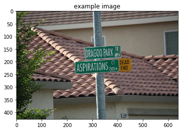

```python
  import numpy as np
  import matplotlib.pyplot as plt
  %matplotlib inline

  # Obtain sample image before and after pre-processing.
  orig_image, image = next(iter(data_loader))

  # Visualize sample image, before pre-processing.
  plt.imshow(np.squeeze(orig_image))
  plt.title('example image')
  plt.show()
```

## 4.1 Load the Models

The model can easily be loaded with the pickle files that were saved at the end of training; these files are essentially checkpoints that allow the model to be quickly rebuilt as it was at the moment training ended with all of the same settings. The only settings that *weren't* saved were `embed_size` and `hidden_size`, so those must be re-defined specifically.

The following does just that:

```python
  import os
  import torch
  from model import EncoderCNN, DecoderRNN

  # Load the following pickles
  encoder_file = "encoder-1.pkl"
  decoder_file = "decoder-1.pkl"

  # Re-define size
  embed_size = 256
  hidden_size = 512

  # Vocabulary
  vocab_size = len(data_loader.dataset.vocab)

  # Initialize encoder and decoder; set each to INFERENCE
  encoder = EncoderCNN(embed_size)
  encoder.eval()
  decoder = DecoderRNN(embed_size, hidden_size, vocab_size)
  decoder.eval()

  # Load trained weights
  encoder.load_state_dict(torch.load(os.path.join('./models', encoder_file)))
  decoder.load_state_dict(torch.load(os.path.join('./models', decoder_file)))

  # Move models to GPU if CUDA available.
  encoder.to(device)
  decoder.to(device)
```

```
DecoderRNN(
  (embed): Embedding(8855, 256)
  (lstm): LSTM(256, 512, batch_first=True)
  (fc): Linear(in_features=512, out_features=8855, bias=True)
)
```

## 4.2 Create the Sampler

The actual work from this section can be found in the `DecoderRNN` class of `model.py` as the `sample` method. This method recieves the Tensor features from the model and outputs a Python list that represents the predicted caption sentence, with each index of that list containing the next predicted word of the full predicted sentence.

The follow code, provided by Udacity, just checks whether my implementation of `sample` breaks anything:

```python
  # Move image Pytorch Tensor to GPU if CUDA available
  image = image.to(device)

  # Obtain embedded image features
  features = encoder(image).unsqueeze(1)

  # Pass embedded image features through model to get predicted caption
  output = decoder.sample(features)
  print('example output:', output)

  assert (type(output)==list), "Output needs to be a Python list"
  assert all([type(x)==int for x in output]), "Output should be a list of integers."
  assert all([x in data_loader.dataset.vocab.idx2word for x in output]), "Each entry in the output needs to correspond to an integer that indicates a token in the vocabulary."
```

```
example output: [0, 3, 33, 30, 21, 3, 33, 30, 39, 46, 18, 1, 1, 18, 1, 1, 18, 1, 1, 18]
```

## 4.3: Clean the Captions

The following function simply takes the output of `sample`, removes the `<start>` and `<end>` tokens, and combines the list elements into a single string; in other words, it cleans it:

```python
  def clean_sentence(output):
  sentence = ""

  for i in output:
      word = data_loader.dataset.vocab.idx2word[i]
      if i ==  0:        # 0 = START
          continue
      elif i == 1:       # 1 = END
          break
      else:
          sentence = sentence + " " + word

  return sentence.strip()
```

Seeing whether this step works, in a way, confirms whether the whole pipeline works – oh, the suspense! Here goes:

```python
  sentence = clean_sentence(output)
  print('example sentence:', sentence)

  assert type(sentence)==str, 'Sentence needs to be a Python string!'
```

```
example sentence: a street sign with a street sign on it .
```

What a profound thing!

## 4.4 Generate Predictions

Finally, we have arrived! The following `get_prediction` function grabs the next image from the loader, runs it through the network, cleans the output, and prints the caption!

Here's the definition of the `get_prediction` function:

```python
      def get_prediction():
      orig_image, image = next(iter(data_loader))
      plt.imshow(np.squeeze(orig_image))
      plt.title('Sample Image')
      plt.show()
      image = image.to(device)
      features = encoder(image).unsqueeze(dim=1)
      output = decoder.sample(features)
      sentence = clean_sentence(output)
      print(sentence)
```

I'll share some hits and misses in a moment; but, for now, here's a cell where you can simply mash `get_prediction()` to your heart's content. If you find any particularly funny ones, you know I'd love to see them!

Note: if you are viewing this project on GitHub Pages, this cell will not be interactive. Before you can *"mash `get_prediction()` to your heart's content"*, you will need to clone the repo. ☹️

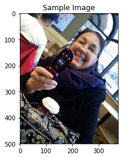

```
a woman is holding a box of doughnuts .
```

```python
get_prediction()
```

## 4.6 The Model Performed Well

Here are some selected examples of the model producing accurate captions for the given image:

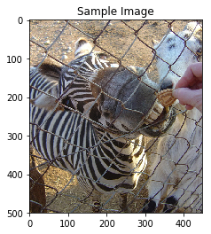

```
a zebra is eating hay from a feeder .
```

```python
get_prediction()
```

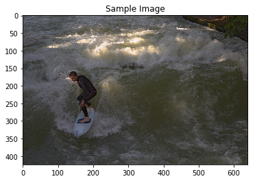

```
a man is surfing on a wave in the ocean .
```

```python
get_prediction()
```

## 4.6 The Model Could Perform Better...

And here are some selected examples of the model *not totally understanding* what's happening in the images:

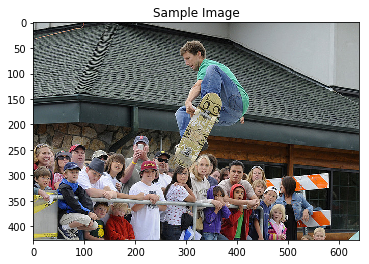

```
a group of people standing around a table with a cake .
```

```python
get_prediction()
```

[figure not shown]

```
a red stop sign sitting on top of a pole .
```

```python
get_prediction()
```

Hey, you win some, and you lose some.

Thanks for reading!

Made by SeanvonB | [Source](https://github.com/SeanvonB/image-captioner)